# NMD analysis: current GENCODE-only scopes (2026-07-10)

Canonical scopes for Figure 3 (D/E/F) + Figure 4 (A/B at all-3-ENST + coding-CDS n=136; C/D at ref-AUG-traceable re-intersected n=888/888). Branched from 05_final_report_mashr.Rmd; that report is now legacy.

2026-07-10

# Overview

This report supersedes `05_final_report_mashr.Rmd` (now legacy-bannered) for the two canonical scopes used in the manuscript’s Figure 3 and Figure 4:

1. **all-3-ENST + coding-CDS (n=136)** — both NMD+ and Control comparators have ENST reference isoforms with a complete coding CDS. Drives Figure 3 D/E/F and Figure 4 Panels A/B + the `CDSand3UTR_GENCODEonly` supplement.
2. **ref-AUG-traceable, re-intersected on `(gene_id, reference_isoform_id)` after category filter (n=888/888)** — drives Figure 4 Panels C/D and the `TD2BiasEvidence` supplement (`n=888` broad, `n=380` occult-PTC).

Analyses kept in the legacy Rmd (per v4 plan): per-cell-type reclassification, two-pass TD2→ref-AUG handoff, the “85% combined” framework, the n=1,904/22,335 GENCODE-only 3’UTR outside-set, and all ORF / model analyses (`06_orf_analysis_mashr.Rmd`).

# §1 — Isopair construction and pair sets

The Stage-2 gene-matched pair cohort (`pop_BC`) is the foundation of every analysis in this report. Construction proceeds in three stages, replicated inline so the cohort can be regenerated without re-running upstream scripts:

1. **Upstream isoform calling and filtering** (`01_prepare_data_mashr.R`) — the long-read isocall count matrix (`nmd_isocall.count_matrix.txt`, 645,273 isoforms × 38 samples; constant defined at the head of `01_prepare_data_mashr.R`) is reduced by removing the 2 DO outlier samples, applying TMM normalization, condition- stratified 5% isoform filter, and `edgeR::filterByExpr`. Output: `expression_data.rds` with 123,790 filtered isoforms × 36 retained samples (6 cell types in the matrix; the 4-CT manuscript scope — AT, DD, FB, MV — covers **26 of those 36 samples**: AT 6 (3 DMSO + 3 SMG1i), DD 8 (4 + 4), FB 6 (3 + 3), MV 6 (3 + 3). The other 10 samples — 6 DD_ALI + 4 DO — are in the matrix but excluded from downstream pair construction and mashr classification per the manuscript scope).
2. **Pair construction** (`02_build_profiles_mashr.R`) — `profiles_c2` pairs the top NMD-sensitive isoform per gene against its dominant non-NMD reference; `profiles_c4` pairs the top-two non-NMD isoforms per gene. Cache: `profiles_c{2,4}_allsamples.rds` (c2 = 1,585 pre-match rows; c4 = 5,038).
3. **Gene-matching** (inline below; replicates `03_nmd_analysis_mashr.Rmd` Stage-2 filter) — restrict both arms to the shared `(gene_id, reference_isoform_id)` set so every gene contributes both a NMD pair and a Control pair under the same reference.

`pop_BC` = 1,585 shared `(gene, reference)` pairs; 1,585 NMD-comp pairs and 1,585 Control-comp pairs — i.e., every gene contributes exactly one of each.

### Cohort cascade — pop_BC through Section A / Section C / TD2 branches

[interactive chart not shown]

The figure-consumer endpoints (gray boxes) tie each cohort to the figures and supplements that consume it: Figure 3 D/E/F and Figure 4 A/B + the CDS/3’UTR supplement Row 1 from Section A; Figure 4 C/D + the CDS/3’UTR supplement Row 2 from Section C; and the TD2BiasEvidence supplement from the n=888 → n=380 occult-PTC chain.

## §1a — Transcript-length comparison

Lengths are recomputed inline from `structures.rds`. The legacy Rmd reported slightly different values because it used the full pre-match c4 set; the pop_BC-restricted Control median is the correct comparator.

Median transcript length (nt): **Reference** = 2,958, **NMD comparator** = 2,991, **Control comparator** = 2,808.

Paired Wilcoxon (each gene contributes one (ref, NMD comp, Control comp) triplet, so paired tests are the correct comparator on this gene-matched design): NMD vs Reference 0.0582; NMD vs Control 5.20e-06; Control vs Reference 1.12e-05.

Transcript length by isoform role (pop_BC scope, nt)

| Group | n | Median | Q25 | Q75 |
| --- | --- | --- | --- | --- |
| Reference (non-NMD) | 1,585 | 2,958 | 1,981 | 4,216 |
| NMD comparator | 1,585 | 2,991 | 2,040 | 4,107 |
| Control comparator | 1,585 | 2,808 | 1,805 | 4,020 |

Paired Wilcoxon: transcript length (gene-matched pairs)

| Comparison | p_value |
| --- | --- |
| NMD vs Reference | 0.0581615 |
| NMD vs Control | 0.0000052 |
| Control vs Reference | 0.0000112 |

## §1b — Annotation status by role

References are predominantly GENCODE-annotated (91.4% ENST, 1,449 / 1,585), while NMD comparators are predominantly novel (77.3%) — consistent with NMD-sensitive transcripts being underrepresented in reference annotations.

Annotation status by role (pop_BC scope)

| Role | n | ENST | Novel | pct_ENST | pct_Novel |
| --- | --- | --- | --- | --- | --- |
| Reference (non-NMD) | 1585 | 1449 | 136 | 91.4 | 8.6 |
| NMD comparator | 1585 | 360 | 1225 | 22.7 | 77.3 |
| Control comparator | 1585 | 754 | 831 | 47.6 | 52.4 |

The Reference %ENST and the NMD-comparator %Novel define the scope reduction that motivates §2 (the GENCODE-only n=136 scope: where ALL three isoforms are ENST-annotated, which constrains the cohort sharply).

## §1c — Per-gene isoform diversity and reference-isoform dominance

The §4¶1 descriptive numbers (median expressed-isoforms per gene; reference- isoform share of parent-gene expression) are computed here from the same pop_BC universe used for transcript-length in §1a, so the SF *PairSetDescriptives* draws from these canonical chunks rather than recomputing.

Across the 1,585 pop_BC genes, the median number of expressed non-NMD isoforms per gene is **7** (IQR = 5). The pop_BC ≥3-isoform inclusion criterion sets the floor.

The median reference-isoform DMSO 4-CT mean expression captures **67%** of the parent gene’s total non-NMD expression; **71%** of references are above the 50% threshold.

## §1d — Figure 3 Panels A/B/C

Panels A (pair-set concept), B (sequence similarity), and C (event prevalence) characterize the pop_BC pair structure. Panel-level methodology is in `figures/multipanel/figure3_isopair_and_ptc/`.

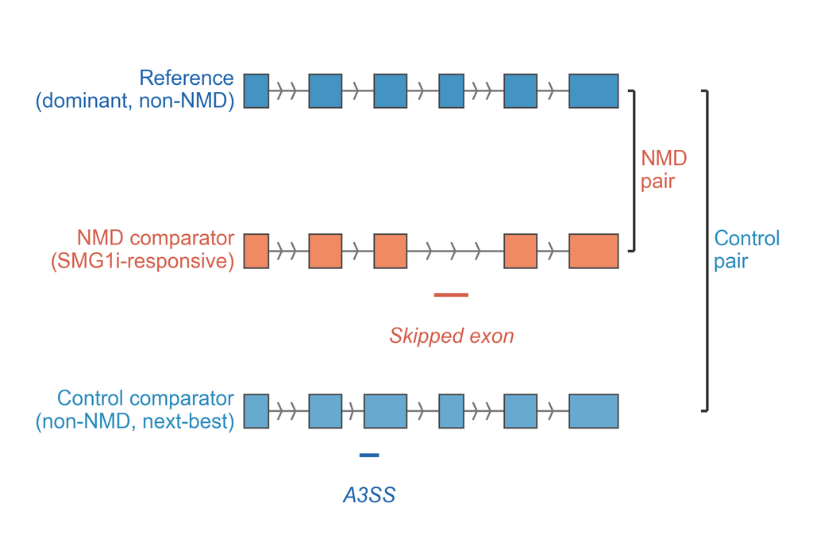

Figure 3 Panel A — Isoform pair construction (schematic)

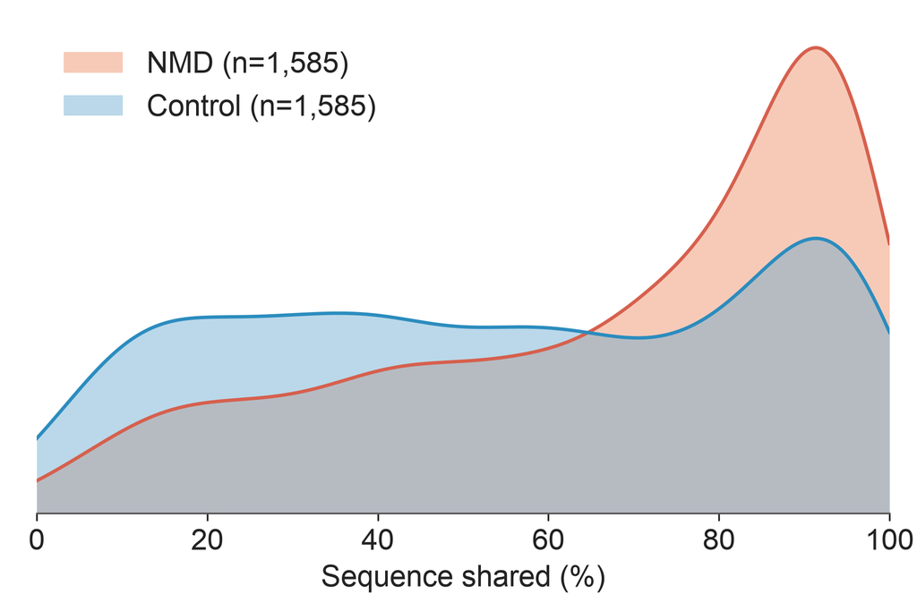

Figure 3 Panel B — Sequence similarity to reference

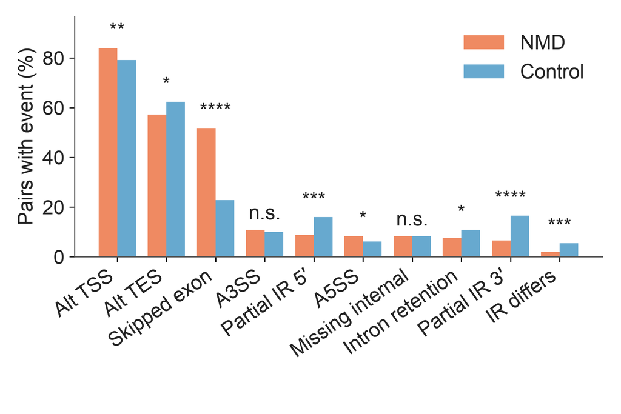

Figure 3 Panel C — Splice event prevalence

# §2 — PTC analysis at the GENCODE-only scope (n=136)

The Section A scope is the most stringent “complete GENCODE-only” subset: every isoform in the pair (Reference, NMD comparator, Control comparator) is GENCODE-annotated (ENST prefix) AND has a curated coding CDS. This eliminates TD2-derived CDS calls from the comparison and gives the cleanest possible PTC-vs-non-PTC contrast.

**Scope construction** (replicated from `figures/multipanel/figure4_ptcneg_and_model/data_export.R` §“Section A scope”):

Filter cascade from pop_BC down to the n=136 Section A scope:

Section A scope cascade — pop_BC → all-ENST → coding-everywhere → gencode_all3 (n=136 / 136)

| Filter step | c2 rows | c4 rows |
| --- | --- | --- |
| pop_BC (gene-matched) | 1,585 | 1,585 |
| + all-ENST (ref & comp) | 196 | NA |
| re-intersect on (gene, ref) | 196 | 196 |
| + coding-CDS everywhere | 146 | 150 |
| re-intersect on (gene, ref) | 136 | 136 |

`gencode_all3_c2` = 136 NMD pairs; `gencode_all3_c4` = 136 Control pairs. Both arms share the same 136 `(gene, reference)` pairs.

## §2a — PTC determination

At this scope every isoform is GENCODE-annotated with a curated coding CDS, so PTC status is determined per comparator from its own annotated stop’s distance to the last exon-exon junction (50-nt rule). No ref-AUG projection is needed. This is the methodology used by Figure 3 Panels D/E/F and is replicated inline from `figures/multipanel/figure3_isopair_and_ptc/data_export.R`.

**PTC+ rates** (own GENCODE stop + 50-nt rule, n=136 NMD pairs / 136 Control pairs):

- NMD: 54 / 136 = **39.7%**
- Control: 1 / 136 = **0.7%**
- Fold enrichment: **54.0×**
- Fisher: OR = 88.1, p = 5.15e-18

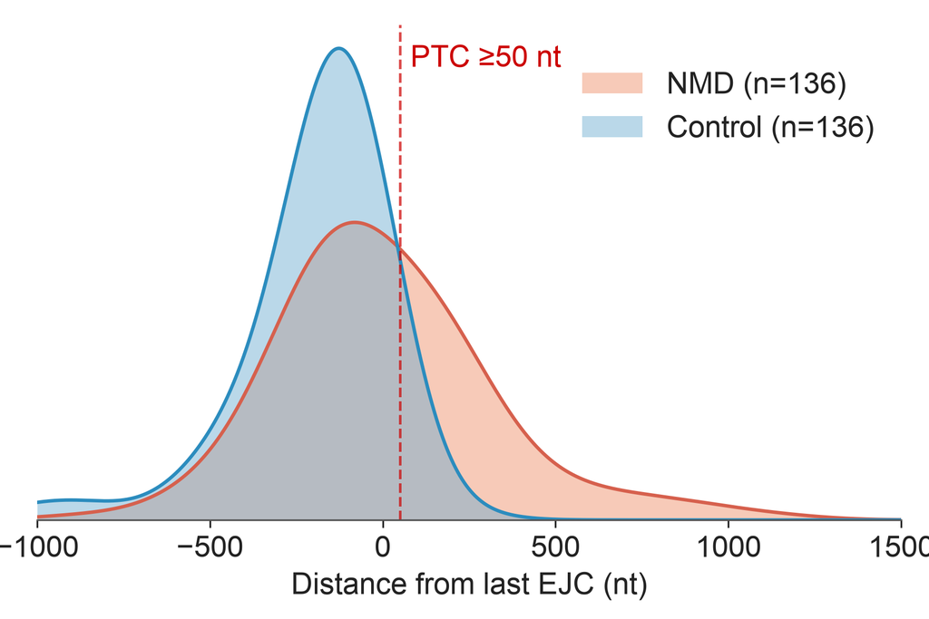

Figure 3 Panel D — Stop-to-last-EJC distance at the n=136 scope

## §2b — PTC-causing event attribution

For each of the 54 PTC+ NMD pairs, we attribute the splice event that introduced the PTC. Two attribution functions are applied:

- `attribute_ptc_events()` — matches a `detailed_events` row to the stop position via `fw_events` (forward-walked junctions); handles the diff-stop case where the comparator’s PTC is at a different genomic position from the reference’s stop.
- `attribute_3utr_splice()` — for same-stop pairs (comparator’s own GENCODE stop equals the reference’s stop), looks for splice events DOWNSTREAM of the stop in the 3’UTR.

For the small set of pairs where both functions return a `"direct"` row, the same-stop call takes precedence (a 3’UTR splice is a more specific attribution than a diff-stop event when the stops coincide).

**Attribution accounting:** 52 direct (from `attribute_ptc_events`) + 6 same-stop 3’UTR splice = 58 total attribution rows → 53 unique direct (same-stop takes precedence over diff-stop; 5 rows were attributed by both functions, with the same-stop call kept) → 1 unresolved out of 54 PTC+ pairs (98.1% attribution coverage).

The pre-combine `attribute_ptc_events` pass left 2 unresolved; the same-stop pass rescued 1 of those, leaving 1 finally unresolved.

**Mechanism breakdown** of the 53 attributed PTC events:

| Mechanism | n |
| --- | --- |
| Frameshift | 30 |
| In-frame stop | 17 |
| 3’UTR splice | 6 |

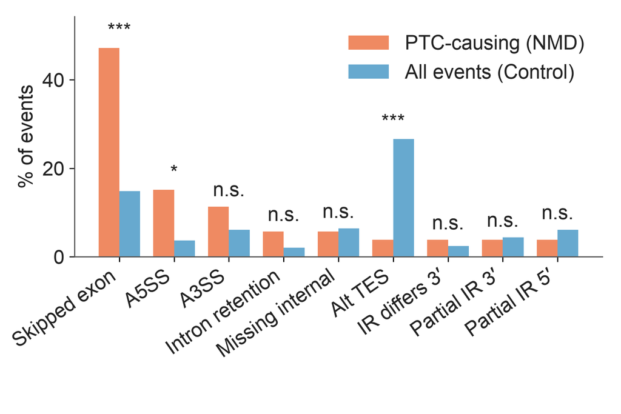

Figure 3 Panel E — PTC-causing event attribution (per-event Fisher table)

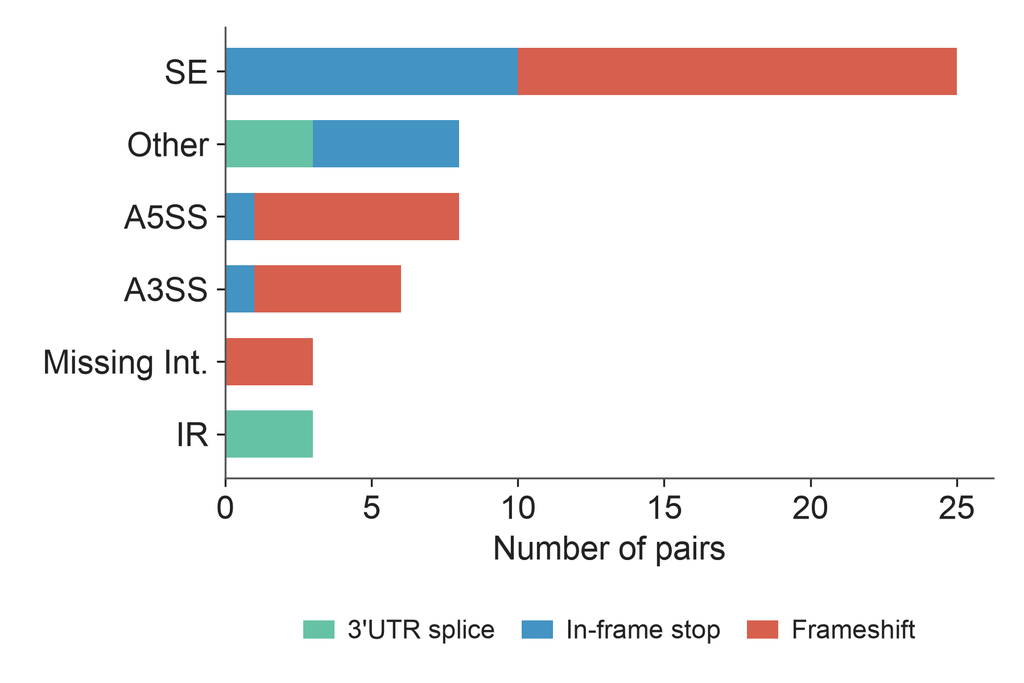

Figure 3 Panel F — Mechanism breakdown × event type

## §2c — 5’UTR length + longest 5’UTR ORF at the n=136 scope

At the n=136 all-3-ENST scope, the 5’UTR is the comparator’s annotated 5’UTR (every isoform is GENCODE-annotated so the TD2-anchored `utr5_features_all` cache value equals the GENCODE 5’UTR length at this scope; the Rmd reads it from cache rather than recomputing). Three groups (using §2a `has_ptc`):

- **NMD+/PTC+** (54 pairs) — `has_ptc == TRUE`
- **NMD+/PTC−** (82 pairs) — `has_ptc == FALSE`
- **Control** (136 pairs) — `gencode_all3_c4` comparators

The Control arm is a single group (not PTC-stratified) because PTC status is a property of the NMD-comparator. This matches the figure-side panel construction.

### Panel A — 5’UTR length

5’UTR length (nt) — Section A descriptives

| Group | n | Median | Q25 | Q75 |
| --- | --- | --- | --- | --- |
| NMD+/PTC+ | 54 | 87.5 | 38.2 | 173.5 |
| NMD+/PTC- | 82 | 426.5 | 318.5 | 690.0 |
| Control | 136 | 145.0 | 64.0 | 296.5 |

5’UTR length — pairwise stats (Hodges–Lehmann shift, Cliff’s δ, Wilcoxon p)

| X | Y | n_X | n_Y | Med X | Med Y | HL shift | HL 95% CI | Cliff’s δ | Wilcoxon p |
| --- | --- | --- | --- | --- | --- | --- | --- | --- | --- |
| NMD+/PTC+ | NMD+/PTC- | 54 | 82 | 87.5 | 426.5 | -326 | [-399.0, -267.0] | -0.799 | 3.67e-15 |
| NMD+/PTC+ | Control | 54 | 136 | 87.5 | 145.0 | -49 | [-89.0, -15.0] | -0.265 | 0.00443 |
| NMD+/PTC- | Control | 82 | 136 | 426.5 | 145.0 | 269 | [210.0, 323.0] | 0.600 | 1.27e-13 |

### Panel B — Longest 5’UTR ORF

Longest 5’UTR ORF (nt) — Section A descriptives

| Group | n | Median | Q25 | Q75 |
| --- | --- | --- | --- | --- |
| NMD+/PTC+ | 54 | 0.0 | 0 | 35.2 |
| NMD+/PTC- | 82 | 244.5 | 156 | 366.0 |
| Control | 136 | 28.5 | 0 | 126.8 |

Longest 5’UTR ORF — pairwise stats

| X | Y | n_X | n_Y | Med X | Med Y | HL shift | HL 95% CI | Cliff’s δ | Wilcoxon p |
| --- | --- | --- | --- | --- | --- | --- | --- | --- | --- |
| NMD+/PTC+ | NMD+/PTC- | 54 | 82 | 0.0 | 244.5 | -213 | [-258.0, -174.0] | -0.806 | 8.90e-16 |
| NMD+/PTC+ | Control | 54 | 136 | 0.0 | 28.5 | 0 | [-30.0, -0.0] | -0.237 | 0.00619 |
| NMD+/PTC- | Control | 82 | 136 | 244.5 | 28.5 | 183 | [156.0, 219.0] | 0.704 | 9.65e-19 |

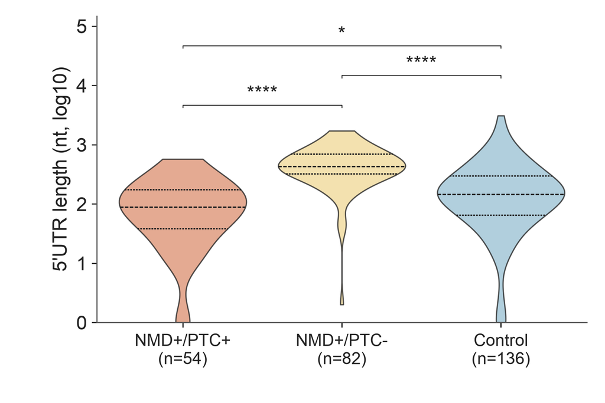

Figure 4 Panel A — 5’UTR length at n=136 scope

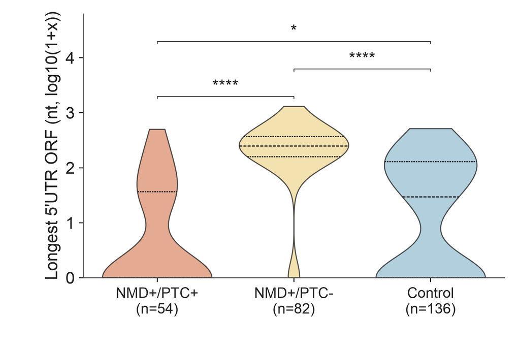

Figure 4 Panel B — Longest 5’UTR ORF at n=136 scope

## §2d — 3’UTR / CDS sanity at n=136

Three additional structural features for the same `sec_A_groups`: CDS length, translation-based 3’UTR (`tx_len − own_stop_tx_pos`), and bias-corrected 3’UTR via the `utr3_via_non_ptc_stop_nt` field of `ref_atg` (walks past PTCs to find the next non-PTC stop). The non-PTC measure is the more meaningful 3’UTR-length comparator because for PTC+ pairs the translation-based 3’UTR inflates with PTC distance and is no longer comparable to the Control 3’UTR.

### CDS length

CDS length (nt)

| Group | n | Median | Q25 | Q75 |
| --- | --- | --- | --- | --- |
| NMD+/PTC+ | 54 | 754.5 | 540.8 | 1206.0 |
| NMD+/PTC- | 82 | 807.0 | 547.5 | 1329.8 |
| Control | 136 | 1048.5 | 588.0 | 1488.0 |

CDS length — pairwise stats

| X | Y | Med X | Med Y | HL shift | HL 95% CI | Cliff’s δ | Wilcoxon p |
| --- | --- | --- | --- | --- | --- | --- | --- |
| NMD+/PTC+ | NMD+/PTC- | 754.5 | 807.0 | -48 | [-192.0, 96.0] | -0.077 | 0.448 |
| NMD+/PTC+ | Control | 754.5 | 1048.5 | -186 | [-366.0, -27.0] | -0.219 | 0.0185 |
| NMD+/PTC- | Control | 807.0 | 1048.5 | -135 | [-294.0, 9.0] | -0.147 | 0.0691 |

### 3’UTR length (translation-based)

3’UTR length, translation-based (own stop → tx end)

| Group | n | Median | Q25 | Q75 |
| --- | --- | --- | --- | --- |
| NMD+/PTC+ | 54 | 869.0 | 512.0 | 1477.8 |
| NMD+/PTC- | 82 | 353.5 | 211.2 | 781.8 |
| Control | 136 | 581.5 | 268.0 | 1153.5 |

3’UTR translation-based — pairwise stats

| X | Y | Med X | Med Y | HL shift | HL 95% CI | Cliff’s δ | Wilcoxon p |
| --- | --- | --- | --- | --- | --- | --- | --- |
| NMD+/PTC+ | NMD+/PTC- | 869.0 | 353.5 | 382 | [231.0, 581.0] | 0.443 | 1.32e-05 |
| NMD+/PTC+ | Control | 869.0 | 581.5 | 282 | [114.0, 455.0] | 0.284 | 0.00226 |
| NMD+/PTC- | Control | 353.5 | 581.5 | -110 | [-245.0, 11.0] | -0.144 | 0.0756 |

### 3’UTR length (bias-corrected, walks past PTCs)

3’UTR length, bias-corrected (non-PTC-stop based)

| Group | n | Median | Q25 | Q75 |
| --- | --- | --- | --- | --- |
| NMD+/PTC+ | 50 | 550.0 | 262.0 | 1067.2 |
| NMD+/PTC- | 82 | 353.5 | 211.2 | 781.8 |
| Control | 136 | 581.5 | 268.0 | 1153.5 |

3’UTR bias-corrected — pairwise stats

| X | Y | Med X | Med Y | HL shift | HL 95% CI | Cliff’s δ | Wilcoxon p |
| --- | --- | --- | --- | --- | --- | --- | --- |
| NMD+/PTC+ | NMD+/PTC- | 550.0 | 353.5 | 117 | [-41.0, 286.0] | 0.149 | 0.152 |
| NMD+/PTC+ | Control | 550.0 | 581.5 | 0 | [-173.0, 167.0] | 0.000 | 1 |
| NMD+/PTC- | Control | 353.5 | 581.5 | -110 | [-245.0, 11.0] | -0.144 | 0.0756 |

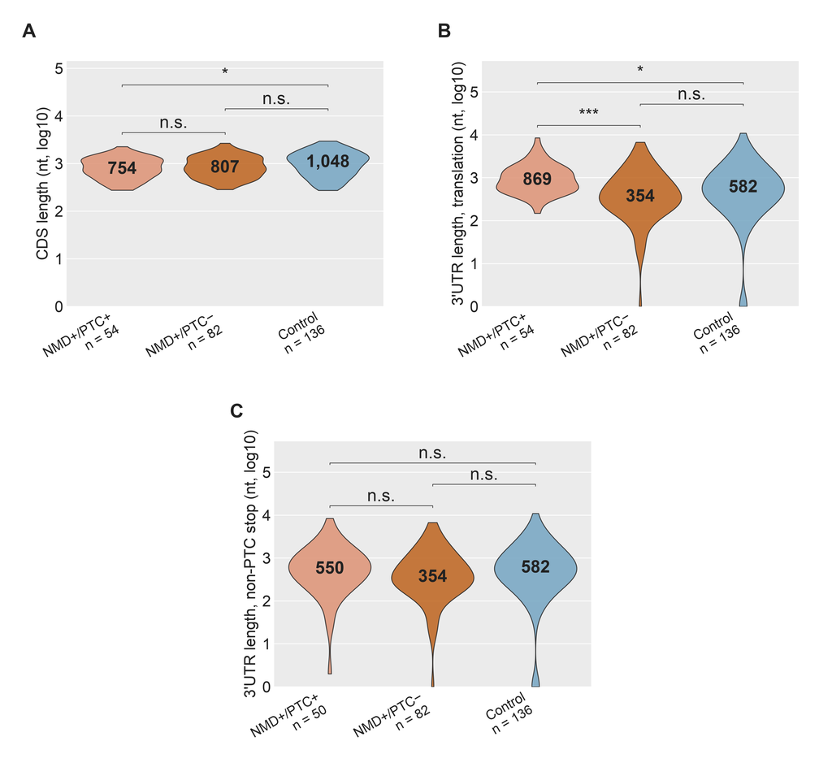

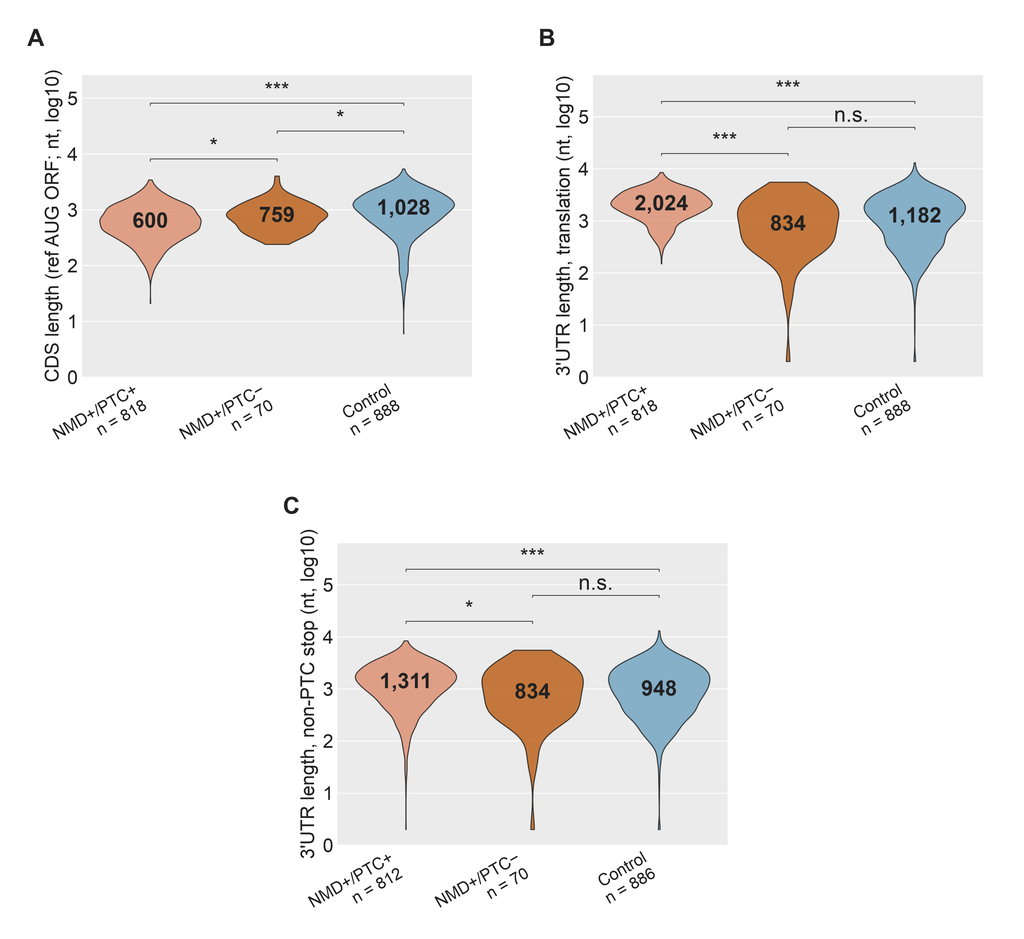

# §3 — Larger-scope replication at ref-AUG-traceable (n=888)

Section C extends Section A by relaxing the all-3-ENST + coding-CDS constraints and instead routing through the ref-AUG-projected ORF classification. This roughly 6× larger cohort lets us check that Section A’s PTC findings replicate at the larger scope without relying on TD2’s CDS calls on novel comparators.

**Scope construction** (replicated from `figures/multipanel/figure4_ptcneg_and_model/data_export.R` §“Section C scope”):

Filter cascade from pop_BC down to the n=888 Section C scope:

Section C scope cascade — pop_BC → ENST-ref → ref-AUG-traceable → re-intersect (n=888 / 888)

| Filter step | c2 rows | c4 rows |
| --- | --- | --- |
| pop_BC (gene-matched) | 1,585 | 1,585 |
| + ENST-reference (no comp constraint) | 1,449 | 1,449 |
| + ref-AUG-traceable category (per side) | 1,233 | 958 |
| re-intersect on (gene, ref) | 888 | 888 |

`refaug_matched_c2` = 888 NMD pairs; `refaug_matched_c4` = 888 Control pairs. Both arms share the same 888 `(gene, reference)` pairs.

**Mechanism classification** of the NMD arm (`mechanism_class_4()` on the ref-AUG-projected ORF category + ORF-length comparison):

Section C NMD-arm 3-group classification

| Group | n |
| --- | --- |
| NMD+/PTC- | 70 |
| NMD+/PTC+ | 818 |

PTC+ rate at this scope: 818 / 888 = 92.1%. This is higher than Section A’s PTC+ rate because the classifier definitions differ — see §5 for reconciliation.

## §3a — 5’UTR length + longest 5’UTR ORF at Section C

At the n=888 scope, most NMD comparators are novel (TD2-anchored CDS not reliable for 5’UTR measurement) — so we use `utr5_features_refaug`, which is the 5’UTR delimited by the ref-AUG-projected start. Three groups (from §3 classification): NMD+/PTC+, NMD+/PTC− (ORF match + ORF diff merged), Control.

### Panel C — 5’UTR length (ref-AUG-anchored)

5’UTR length (nt) — Section C descriptives

| Group | n | Median | Q25 | Q75 |
| --- | --- | --- | --- | --- |
| NMD+/PTC+ | 818 | 237 | 134.0 | 409.8 |
| NMD+/PTC- | 70 | 409 | 232.2 | 619.2 |
| Control | 888 | 185 | 92.0 | 339.5 |

5’UTR length — pairwise stats

| X | Y | n_X | n_Y | Med X | Med Y | HL shift | HL 95% CI | Cliff’s δ | Wilcoxon p |
| --- | --- | --- | --- | --- | --- | --- | --- | --- | --- |
| NMD+/PTC+ | NMD+/PTC- | 818 | 70 | 237 | 409 | -134 | [-196.0, -73.0] | -0.304 | 2.36e-05 |
| NMD+/PTC+ | Control | 818 | 888 | 237 | 185 | 46 | [29.0, 63.0] | 0.153 | 4.42e-08 |
| NMD+/PTC- | Control | 70 | 888 | 409 | 185 | 180 | [123.0, 242.0] | 0.425 | 3.13e-09 |

### Panel D — Longest 5’UTR ORF (ref-AUG-anchored)

Longest 5’UTR ORF (nt) — Section C descriptives

| Group | n | Median | Q25 | Q75 |
| --- | --- | --- | --- | --- |
| NMD+/PTC+ | 818 | 33 | 0.0 | 161.2 |
| NMD+/PTC- | 70 | 165 | 55.5 | 294.0 |
| Control | 888 | 0 | 0.0 | 114.0 |

Longest 5’UTR ORF — pairwise stats

| X | Y | n_X | n_Y | Med X | Med Y | HL shift | HL 95% CI | Cliff’s δ | Wilcoxon p |
| --- | --- | --- | --- | --- | --- | --- | --- | --- | --- |
| NMD+/PTC+ | NMD+/PTC- | 818 | 70 | 33 | 165 | -81 | [-135.0, -54.0] | -0.331 | 1.86e-06 |
| NMD+/PTC+ | Control | 818 | 888 | 33 | 0 | 0 | [0.0, 0.0] | 0.088 | 9.61e-04 |
| NMD+/PTC- | Control | 70 | 888 | 165 | 0 | 93 | [66.0, 147.0] | 0.407 | 1.68e-09 |

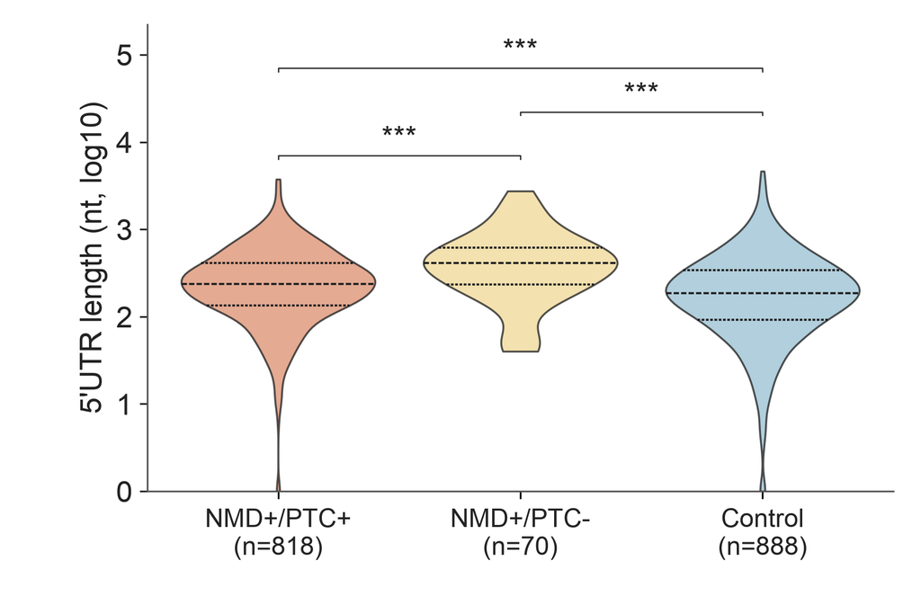

Figure 4 Panel C — 5’UTR length at n=888 scope

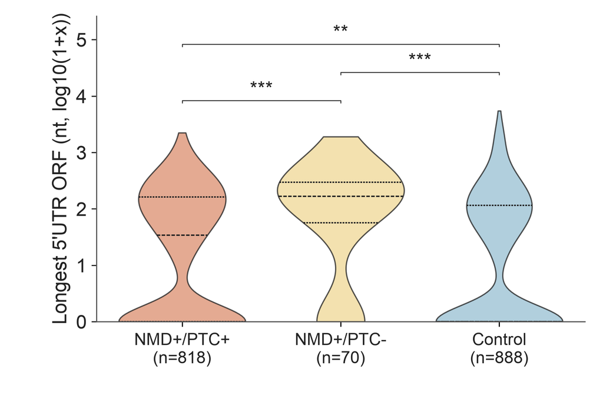

Figure 4 Panel D — Longest 5’UTR ORF at n=888 scope

# §4 — TD2 bias evidence (TD2BiasEvidence supplement)

Scope (broad): `refaug_matched_c2 ∩ TD2 CDS available ∩ ref-AUG ORF computable ∩ ref AUG exonic` → n=888 broad. Scope (occult-PTC): broad `∩ effectively_ptc ∩ original_ptc == FALSE` → n=380.

**Scope construction.** Broad (n=888) = `refaug_matched_c2` ∩ TD2 CDS available ∩ ref-AUG ORF computable ∩ ref AUG exonic. Occult-PTC (n=380) = broad ∩ `category == "effectively_ptc"` ∩ `original_ptc == FALSE` — pairs where ref-AUG tracing revealed a PTC that TD2 missed. This is the population in which TD2’s PTC-avoidance bias is most pronounced.

`broad` = 888 pairs (matches the n=888 TD2BiasEvidence supplement scope).

## §4a — TD2 vs ref-AUG ORF length

| Scope | n | TD2 median ORF (nt) | ref-AUG median ORF (nt) | TD2/ref ratio |
| --- | --- | --- | --- | --- |
| Broad | 888 | 2,776.5 | 613.5 | **4.53×** |
| Occult-PTC | 380 | 2,911.5 | 379.5 | **7.67×** |

## §4b — Paired Kozak PWM at ref AUG vs TD2 ATG

The “ref > TD2 (% of all)” column counts pairs where the ref-AUG Kozak score exceeds TD2’s — pooled over all pairs including ties (broad scope has many pairs where TD2 == ref AUG, distance 0). The “% of non-tied” column drops ties so the directional preference is unobscured. The paired-Wilcoxon p-value is computed on the raw score vector, ignoring ties as `wilcox.test` does.

| Scope | n | ref > TD2 | ties | ref > TD2 (% of all) | ref > TD2 (% of non-tied) | Paired-Wilcoxon p |
| --- | --- | --- | --- | --- | --- | --- |
| Broad | 888 | 343 | 461 | 38.6% | 80.3% | 2.92e-39 |
| Occult-PTC | 380 | 310 | 0 | 81.6% | 81.6% | 5.17e-38 |

## §4c — TD2 ATG position relative to ref AUG

| Scope | n | TD2 == ref | TD2 downstream | TD2 upstream | % downstream |
| --- | --- | --- | --- | --- | --- |
| Broad | 888 | 461 | 381 | 46 | **42.9%** |
| Occult-PTC | 380 | 0 | 375 | 5 | **98.7%** |

In the occult-PTC scope, **TD2 selects an ATG downstream of the ref-AUG in 98.7% of pairs**, with a Kozak score lower than the ref-AUG in 81.6% of pairs (paired-Wilcoxon 5.17e-38). The TD2 ORF is 7.67× LONGER than the ref-AUG-projected ORF (ratio of medians) — TD2 picks a downstream ATG that extends past the PTC into an in-frame coding region, producing a longer ORF that lacks the EJC-downstream stop that defines a PTC. Together these three signals describe TD2’s PTC-avoidance bias: TD2 systematically routes around occult PTCs by picking a downstream ATG, even at the cost of a lower Kozak score.

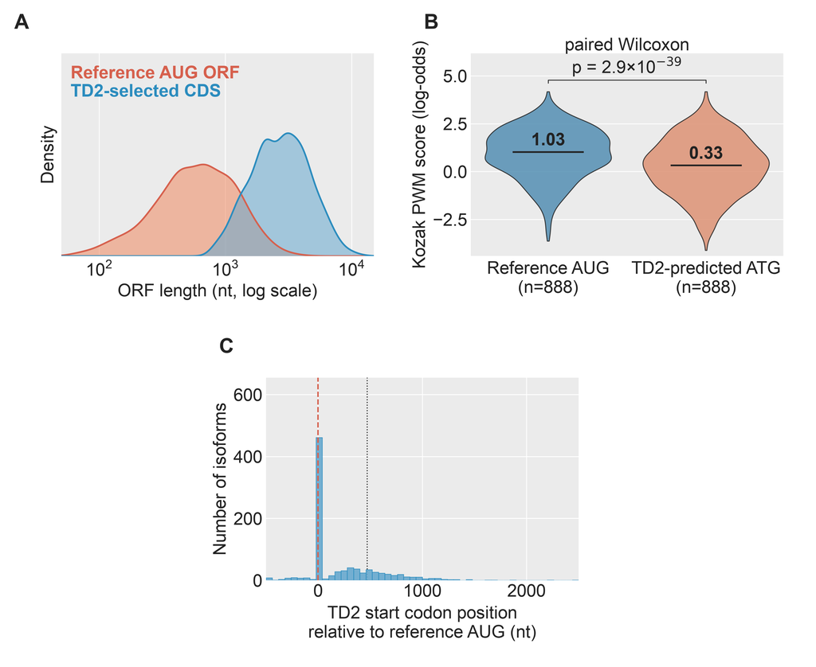

TD2BiasEvidence supplement — 2×3 layout: broad scope (row 1, n=888) + occult-PTC scope (row 2, n=380)

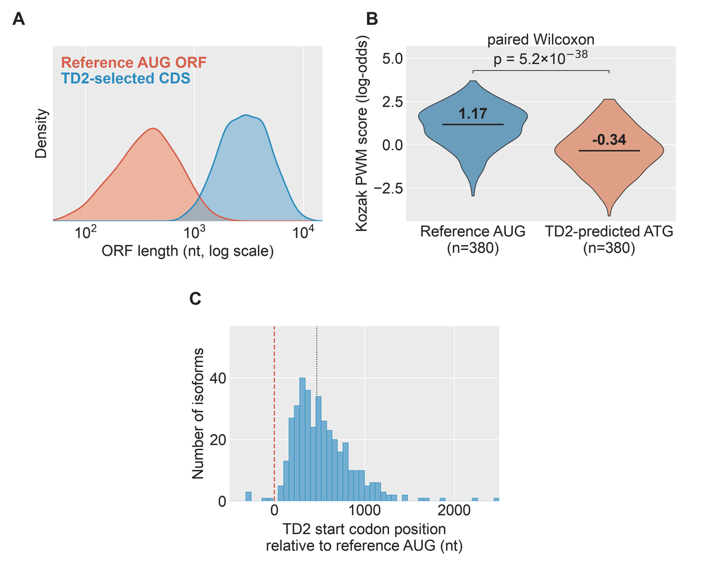

TD2BiasEvidence supplement — 2×3 layout: broad scope (row 1, n=888) + occult-PTC scope (row 2, n=380)

# §5 — Cumulative accounting [verification chokepoint]

Recompute from §2 / §3 result objects so the totals in this report can be audited end-to-end without trusting upstream caches.

Cumulative accounting at both canonical scopes

| Scope | PTC+ | PTC− | Ref AUG absent | Total | PTC+ rate (%) |
| --- | --- | --- | --- | --- | --- |
| Section A (n=136) | 54 | 82 | NA | 136 | 39.7 |
| Section C (n=888) | 818 | 70 | 0 | 888 | 92.1 |

- **Section A (n=136):** 54 PTC+ and 82 PTC− sum to 136. PTC+ rate **39.7%**.
- **Section C (n=888):** 818 PTC+, 70 PTC−, and 0 Ref-AUG-absent sum to 888. PTC+ rate **92.1%**.

**Why the two scopes give different PTC+ rates** is a methodological — not biological — divergence:

| Difference | Section A | Section C |
| --- | --- | --- |
| Cohort filter | all-3-ENST + coding-CDS (most stringent) | ENST-reference only (broader) |
| PTC classifier | own-GENCODE-stop + 50-nt rule | ref-AUG-projected `category == "effectively_ptc"` |
| Comparator CDS source | curated GENCODE | TD2 (heavily debiased via ref-AUG projection) |
| Selection-on-PTC | none — every coding-CDS comparator measured | TR-category filter requires ref-AUG-traceable ORF — pairs where ref-AUG points at “no_downstream_ejc” or “truncated_no_ejc” classify as PTC− regardless of comparator’s own stop |

# §6 — What is intentionally NOT in this Rmd

These analyses remain in `05_final_report_mashr.Rmd` (legacy-bannered) or `06_orf_analysis_mashr.Rmd` (legacy-bannered) — they are retained for reproducibility of the prior submission and for sensitivity analyses:

- Reclassification two-pass (TD2 → ref-AUG handoff at the old scope) — legacy `05_final_report_mashr.Rmd`.
- Per-cell-type PTC stratification at the old scope — legacy `05_final_report_mashr.Rmd`.
- “85% combined” framework — legacy `05_final_report_mashr.Rmd`.
- n=1,904 / n=22,335 GENCODE-only 3’UTR outside-set — legacy `05_final_report_mashr.Rmd`.
- ORF / deep-learning model analyses — `06_orf_analysis_mashr.Rmd` (in this repo, legacy). The canonical home of the manuscript deep-learning model is the **linked repo `peter4244/NMD_orf_model_v5_4ct`**: `03_train.py`, `config.yaml`, `model.py`, `METHODS.md`, plus DeepSHAP / KernelSHAP scripts. The “ORF identification is the bottleneck” headline result lives there.

Cross-cell-type consistency checks are out of scope for this Rmd; per-CT mashr CSVs in `shortread_dge/mashr/` and `isocall_dge/mashr/` are the source of truth for CT-stratified numbers.